# Single-cell RNA-seq data analysis of project 10x_pbmc_5k

Identification of multiplets

[Dresden-concept Genome Center, TU Dresden](https://genomecenter.tu-dresden.de/)

[Research Core Unit Genomics, Hannover Medical School](https://www.mhh.de/genomics)

Mai, 2021

```r
# R Options
options(stringsAsFactors=FALSE,
        "citation_format"="pandoc",
        dplyr.summarise.inform=FALSE,
        knitr.table.format="html",
        future.globals.maxSize=2000000000, mc.cores=4,
        future.fork.enable=TRUE, future.plan="multicore",
        future.rng.onMisuse="ignore")

# Required libraries
library(Seurat) # main
library(ggplot2) # plots
library(patchwork) # combination of plots
library(magrittr) # %>% operator

# Other libraries we use
# Knit: knitr
# Data handling: dplyr, tidyr, purrr
# Tables: kableExtra
# Plots: ggsci

# Knitr default options
knitr::opts_chunk$set(echo=TRUE,                     # output code
                      cache=FALSE,                   # do not cache results
                      message=TRUE,                  # show messages
                      warning=TRUE,                  # show warnings
                      tidy=FALSE,                    # do not auto-tidy-up code
                      fig.width=10,                  # default fig width in inches
                      class.source='fold-hide',      # by default collapse code blocks
                      dev=c('png', 'pdf'),           # create figures in png and pdf; the first device (png) will be used for HTML output
                      dev.args=list(png=list(type="cairo"),  # png: use cairo - works on cluster, supports anti-aliasing (more smooth)
                                    pdf=list(bg="white")),     # pdf: use cairo - works on cluster, supports anti-aliasing (more smooth)
                      dpi=96,                        # figure resolution (note: final = dpi*fig.retina; will not work with pandoc see below)
                      fig.retina=2                   # retina multiplier for HTML output (note: final = dpi*fig.retina)

)
```

```r
# Path for figures in png and pdf format
knitr::opts_chunk$set(fig.path=paste(params$path_out, "figures/", sep="/"))


# Git directory and files to source must be done first, then all helper functions can be sourced
git_files_to_source = c("R/functions_io.R",
              "R/functions_plotting.R",
              "R/functions_util.R")
git_files_to_source = paste(params$path_to_git, git_files_to_source, sep="/")
file_exists = purrr::map_lgl(git_files_to_source, file.exists)

if (any(!file_exists)) stop(paste("The following files could not be found:",paste(git_files_to_source[!file_exists], collapse=", "), ". Please check the git directory at '", params$path_to_git, "'.!"))
invisible(purrr::map(git_files_to_source, source))

# Debugging mode:
# 'default_debugging' for default, 'terminal_debugger' for debugging without X11, 'print_traceback' for non-interactive sessions
invisible(switch (params$debugging_mode,
        default_debugging=on_error_default_debugging(),
        terminal_debugger=on_error_start_terminal_debugger(),
        print_traceback=on_error_just_print_traceback(),
        on_error_default_debugging()))

# Set output hooks
knitr::knit_hooks$set(message=format_message, warning=format_warning)

# Create output directories
if (!file.exists(params$path_out)) dir.create(params$path_out, recursive=TRUE, showWarnings=FALSE)

# Do checks
error_messages = c()
# Check installed packages
error_messages = c(error_messages, check_installed_packages())
# Check parameters TODO
#error_messages = c(error_messages, check_parameters(param))

# Stop here if there are errors
if (length(error_messages)) stop(paste(c("", paste("*", error_messages)), collapse="\n"))
```

# Read input data

In this first section of the report, we begin by printing mapping statistics that have been produced prior to this workflow.

```r
# Are statistics provided?
if (!is.null(params$stats)) {
  cat('\n## Stats {.tabset}\n\n')
  mapping_stats = read.delim(params$stats,sep=",", header=FALSE, check.names=FALSE) %>% t() %>% as.data.frame()
  colnames(mapping_stats) = c("V1","Dataset")
  rownames(mapping_stats) = mapping_stats$V1
  mapping_stats$V1 = NULL

  mapping_stats_general = mapping_stats[!grepl("^Antibody:",rownames(mapping_stats)),,drop=FALSE]
  mapping_stats_antibodies = mapping_stats[grepl("^Antibody:",rownames(mapping_stats)),,drop=FALSE]

  cat('\n### General\n\n')
  print(knitr::kable(mapping_stats_general, align="l", caption="General statistics") %>%
  kableExtra::kable_styling(bootstrap_options=c("striped", "hover")))

  cat('\n### Antibodies\n\n')
  print(knitr::kable(mapping_stats_antibodies, align="l", caption="Antibody statistics") %>%
  kableExtra::kable_styling(bootstrap_options=c("striped", "hover")))
} else {
  message("Mapping statistics cannot be shown. No valid file provided.")
}
```

## Stats

### General

General statistics

|  | Dataset |
| --- | --- |
| Estimated Number of Cells | 5,247 |
| Mean Reads per Cell | 28,917 |
| Median Genes per Cell | 1,646 |
| Number of Reads | 151,731,342 |
| Valid Barcodes | 97.5% |
| Sequencing Saturation | 52.4% |
| Q30 Bases in Barcode | 95.8% |
| Q30 Bases in RNA Read | 91.9% |
| Q30 Bases in Sample Index | 89.8% |
| Q30 Bases in UMI | 95.4% |
| Reads Mapped to Genome | 94.3% |
| Reads Mapped Confidently to Genome | 88.4% |
| Reads Mapped Confidently to Intergenic Regions | 6.8% |
| Reads Mapped Confidently to Intronic Regions | 25.0% |
| Reads Mapped Confidently to Exonic Regions | 56.7% |
| Reads Mapped Confidently to Transcriptome | 53.2% |
| Reads Mapped Antisense to Gene | 1.3% |
| Fraction Reads in Cells | 87.7% |
| Total Genes Detected | 20,840 |
| Median UMI Counts per Cell | 5,506 |

### Antibodies

Antibody statistics

|  | Dataset |
| --- | --- |
| Antibody: Number of Reads | 39,096,673 |
| Antibody: Mean Reads per Cell | 7,451 |
| Antibody: Valid Barcodes | 99.0% |
| Antibody: Sequencing Saturation | 39.6% |
| Antibody: Q30 Bases in Barcode | 96.7% |
| Antibody: Q30 Bases in Antibody Read | 96.0% |
| Antibody: Q30 Bases in Sample Index | 87.5% |
| Antibody: Q30 Bases in UMI | 96.8% |
| Antibody: Fraction Antibody Reads | 94.3% |
| Antibody: Fraction Antibody Reads Usable | 67.4% |
| Antibody: Antibody Reads Usable per Cell | 5,022 |
| Antibody: Fraction Reads in Barcodes with High UMI Counts | 0.0% |
| Antibody: Fraction Unrecognized Antibody | 5.7% |
| Antibody: Antibody Reads in Cells | 72.1% |
| Antibody: Median UMIs per Cell (summed over all recognized antibody barcodes) | 2,757 |

# Filtering and normalisation/scaling

Then, we read 10X data from the files produced by CellRanger:

- **barcodes.tsv.gz**: All cell barcodes
- **features.tsv.gz**: (Ensembl) ID, name, and type for each feature
- **matrix.mtx.gz**: Counts for all features

and setup a Seurat object with the **Gene Expresssion** data in assay **RNA**.

```r
# Load the dataset with its assays and create a Seurat object with the **Gene Expresssion** data in assay **RNA**.
sc = ReadSparseMatrix(params$path_data, project=params$project_id, row_name_column=1)
```

× **(Message)**  
10X data contains more than one type and is being returned as a list containing matrices of each type.

```r
sc = sc[[1]]

# If requested: sample at most n cells
if (!is.null(params$downsample_cells_n)) {
  sampled_barcodes = sample(Seurat::Cells(sc), min(params$downsample_cells_n, length(Seurat::Cells(sc))))
  sc = subset(sc, cells=sampled_barcodes)
}

# Calculate percentage of counts in mitochondrial genes
mt_features = grep(pattern=params$mt_names, rownames(sc), value=TRUE)
sc = Seurat::PercentageFeatureSet(sc, features=mt_features, col.name="percent_mt", assay="RNA")

# Calculate percentage of counts in ribosomal genes
ribo_features = grep(pattern="^RP[SL]", rownames(sc), value=TRUE, ignore.case=TRUE)
sc = Seurat::PercentageFeatureSet(sc, features=ribo_features, col.name="percent_ribo", assay="RNA")

# Calculate percentage of counts in ERCC for each Seurat object (if assay is available)
if ("ERCC" %in% Seurat::Assays(sc)) {
  sc$percent_ercc = sc$nCount_ERCC/(sc$nCount_ERCC + sc$nCount_RNA)*100
}
```

To ensure that input data is cleared of low-quality cell clusters, we first threshold cells according to RNA nCount, nFeature and percent_mt. Cells filtered based on the following thresholds:

```r
cell_filter_lst = params$cell_filter
is_numeric_filter = purrr::map_lgl(cell_filter_lst, function(f) return(is.numeric(f) & length(f)==2))

# Numeric cell filters
if (length(cell_filter_lst[is_numeric_filter]) > 0) {
  purrr::invoke(rbind, cell_filter_lst[is_numeric_filter]) %>%
    knitr::kable(align="l", caption="Numeric filters applied to cells", col.names=c("Min", "Max")) %>%
    kableExtra::kable_styling(bootstrap_options=c("striped", "hover"))
}
```

Numeric filters applied to cells

|  | Min | Max |
| --- | --- | --- |
| nFeature_RNA | 200 | NA |
| percent_mt | NA | 20 |
| nCount_RNA | 1000 | NA |

```r
# Categorial cell filters
if (length(cell_filter_lst[!is_numeric_filter]) > 0) {
purrr::invoke(rbind, cell_filter_lst[!is_numeric_filter] %>% purrr::map(paste, collapse=",")) %>%
  knitr::kable(align="l", caption="Categorial filters applied to cells", col.names=c("Values")) %>%
  kableExtra::kable_styling(bootstrap_options=c("striped", "hover"))
}
```

The number of excluded cells and features is as follows:

```r
# Iterate over datasets and filters
# Record a cell if it does not pass the filter
sc_cells_to_exclude = purrr::map(list_names(params$cell_filter), function(f) {
  filter = params$cell_filter[[f]]
  if (is.numeric(filter)) {
    if (is.na(filter[1])) filter[1] = -Inf # Minimum
    if (is.na(filter[2])) filter[2] = Inf  # Maximum
    idx_exclude = sc[[f, drop=TRUE]] < filter[1] | sc[[f, drop=TRUE]] > filter[2]
    return(names(which(idx_exclude)))
  } else if (is.character(filter)) {
    return(names(which(sc[[f, drop=TRUE]] %in% filter)))
  }
})


# Summarise
sc_cells_to_exclude_summary = purrr::map_dfr(sc_cells_to_exclude, function(s) {
  return(data.frame(cells=length(s)))
})

rownames(sc_cells_to_exclude_summary) = names(sc_cells_to_exclude)
knitr::kable(sc_cells_to_exclude_summary, align="l", caption="Number of excluded cells") %>%
  kableExtra::kable_styling(bootstrap_options=c("striped", "hover"))
```

Number of excluded cells

|  | cells |
| --- | --- |
| nFeature_RNA | 50 |
| percent_mt | 0 |
| nCount_RNA | 258 |

```r
# Now filter
cells_to_keep = Cells(sc)
cells_to_keep = cells_to_keep[!cells_to_keep %in% purrr::flatten_chr(sc_cells_to_exclude)]
if (length(cells_to_keep)==0) stop("Error: no cells remaining after filtering!")
sc = subset(sc, cells=cells_to_keep)
```

After filtering, the size of the Seurat object is:

```r
sc
```

```
## An object of class Seurat
## 33570 features across 4985 samples within 2 assays
## Active assay: RNA (33538 features, 0 variable features)
##  1 other assay present: ADT
```

Then, we normalise, identify genes that are highly variable between cells and scale those genes. There are two types of normalisation strategy available:

1. A **standard log normalisation**, where counts for each cell are divided by the total counts for that cell and multiplied by 10,000. This is then natural-log transformed.
2. **SCTransform**, a new and more sophisticated normalisation method which includes normalisation, variable genes and scaling.

```r
if (params$norm == "LogNormalize") {
  # Standard normalisation
  sc = Seurat::NormalizeData(sc, normalization.method="LogNormalize", scale.factor=10000, verbose=FALSE)

  # Find variable features from normalised data
  sc = Seurat::FindVariableFeatures(sc, selection.method="vst", nfeatures=3000, verbose=FALSE)

  # Scale data: the DoubletFinder tutorial uses only the variable genes but according to "Protocol for Benchmarking Computational Doublet-Detection Methods in Single-Cell RNA Sequencing" it might be better to scale all genes
  sc = Seurat::ScaleData(sc, features=rownames(sc[["RNA"]]), verbose=FALSE, vars.to.regress=c())
} else if (params$norm == "SCTransform") {

  # Run SCTransform: as for the standard normalisation strategy, we scale all data
  sc = SCTransform(sc, vars.to.regress=c(), min_cells=3, verbose=FALSE, return.only.var.genes=FALSE, method=ifelse(packages_installed("glmGamPoi"), "glmGamPoi", "poisson"))
}
```

# Dimensionality reduction, clustering and visualisation

Next, we use Principal Component Analysis (PCA) to overcoming noise and reducing the data to its essential components. Each principal component (PC) represents a “metafeature” that combines information across a correlated gene set. Then we also calculate a basic clustering of the data and use Uniform Manifold Approximation and Projection (UMAP) to visualise the dataset in 2D space. Note that here we use non-optimised standard algorithms. In a comprehensive single cell analysis, these algorithms are usually tuned to yield optimal results.

```r
# Run PCA
sc = Seurat::RunPCA(sc, features=Seurat::VariableFeatures(object=sc), verbose=FALSE)

# Choose the number of PCs to use for clustering
sc = Seurat::FindNeighbors(sc, dims=1:params$pc_n, verbose=FALSE)

# Find clusters using Seurats standard algorithm
sc = Seurat::FindClusters(sc, resolution=0.5, algorithm=1, verbose=FALSE)

# Set cluster colors
cluster_names = levels(sc$seurat_clusters)
sc_col_clusters = GenerateColours(num_colours=length(cluster_names), palette="ggsci::pal_d3", palette_options = list(palette="category20"))
names(sc_col_clusters) = cluster_names

# Run UMAP
sc = Seurat::RunUMAP(sc, dims=1:params$pc_n, verbose=FALSE, umap.method="uwot")
```

```r
# Plot pca
p1 = Seurat::DimPlot(sc, reduction="pca", cols=sc_col_clusters, label=TRUE) +
  AddStyle(title="Cells arranged by the first two PCs", legend_position="bottom", legend_title="Clusters")
```

× **(Warning)** Using `as.character()` on a quosure is deprecated as of rlang 0.3.0.  
Please use `as_label()` or `as_name()` instead.  
This warning is displayed once per session.

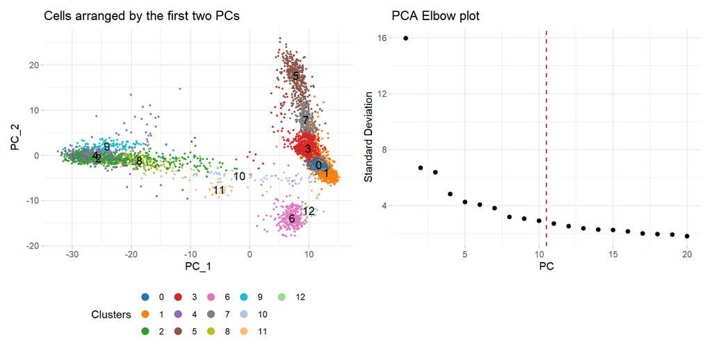

```r
p2 = Seurat::ElbowPlot(sc, ndims=min(20, ncol(sc))) +
  geom_vline(xintercept=params$pc_n + .5, col="firebrick", lty=2) +
  AddStyle(title="PCA Elbow plot")

patchwork::wrap_plots(p1, p2)
```

We use a UMAP to visualise and explore a dataset. The goal is to place similar cells together in 2D space, and learn about the biology underlying the data. Cells are color-coded according to the graph-based clustering, and clusters typcially co-localise on the UMAP.

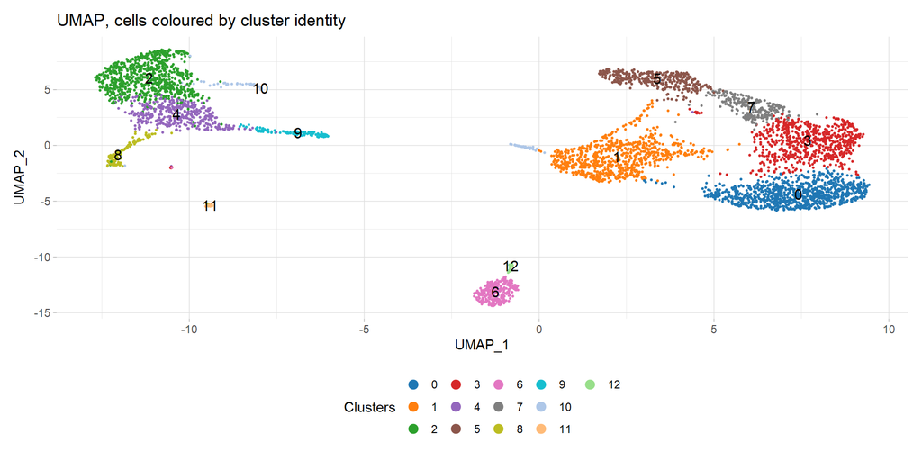

```r
# Note that you can set `label = TRUE` or use the LabelClusters function to help label individual clusters
cluster_cells = table(sc@active.ident)
cluster_labels = paste0(levels(sc@active.ident)," (", cluster_cells[levels(sc@active.ident)],")")
p = Seurat::DimPlot(sc, reduction="umap", label=TRUE) +
  AddStyle(title="UMAP, cells coloured by cluster identity", legend_position="bottom", legend_title="Clusters") +
  scale_color_manual(values=sc_col_clusters)
p
```

# Doublet detection

```r
# Identification of optimal pK
sweep.res.list_sc = DoubletFinder::paramSweep_v3(sc, PCs=1:params$pc_n, sct=params$norm == "SCTransform")
sweep.stats_sc = DoubletFinder::summarizeSweep(sweep.res.list_sc, GT=FALSE)
bcmvn_sc = DoubletFinder::find.pK(sweep.stats_sc)

# Estimate the number of loaded cells
num_loaded_cells = 2*ncol(sc)

# Estimate the doublet rate: 10x says 0.8% / 1000 loaded cells
exp_doublet_rate = num_loaded_cells/1000*0.008

# Estimated number of doublets based on poison distribution
nExp_poi = round(0.15*length(Cells(sc)))

# Run DoubletFinder
sc = DoubletFinder::doubletFinder_v3(sc, PCs=1:params$pc_n, pN=0.25, pK=0.25, nExp=exp_doublet_rate, reuse.pANN=FALSE, sct=params$norm == "SCTransform")
```

# Parameter table

The following parameters were used to run the workflow.

```r
out = ScrnaseqParamsInfo(params=params)

knitr::kable(out, align="l") %>%
  kableExtra::kable_styling(bootstrap_options = c("striped", "hover"), full_width=FALSE, position="left")
```

| Name | Value |
| --- | --- |
| project_id | 10x_pbmc_5k |
| path_data | test_datasets/10x_pbmc_5k_protein/counts/ |
| stats | test_datasets/10x_pbmc_5k_protein/metrics_summary.csv |
| path_out | test_datasets/10x_pbmc_5k_protein/counts/ |
| norm | LogNormalize |
| mt_names | ^MT- |
| cell_filter | nFeature_RNA:200, NA; percent_mt:NA, 20; nCount_RNA:1000, NA |
| pc_n | 10 |
| col | palevioletred |
| downsample_cells_n |  |
| path_to_git | . |
| debugging_mode | on_error_default_debugging |

# Software versions

This report was generated using the scrnaseq GitHub repository. Software versions were collected at run time.

```r
out = ScrnaseqSessionInfo(params$path_to_git)
```

× **(Message)**  
Registered S3 method overwritten by ‘cli’:  
method from  
print.boxx spatstat

```r
knitr::kable(out, align="l") %>%
  kableExtra::kable_styling(bootstrap_options = c("striped", "hover"), full_width=FALSE, position="left")
```

| Name | Version |
| --- | --- |
| ktrns/scrnaseq | 8107ff69f155de2c4acd3613ddf67a828608a189 |
| R | R version 3.6.3 (2020-02-29) |
| Platform | x86_64-w64-mingw32/x64 (64-bit) |
| Operating system | Windows 10 x64 (build 19041) |
| Packages | abind1.4-5, assertthat0.2.1, cli2.2.0, cluster2.1.0, codetools0.2-18, colorspace2.0-0, cowplot1.1.0, crayon1.3.4, data.table1.13.4, deldir0.2-3, digest0.6.27, dplyr1.0.2, ellipsis0.3.1, evaluate0.14, … |